# Homework #1 Programming Assignment Solution

Most of functions in this homework are saved in the following notebooks.

Basic Functions.ipynb

Binary Huffman Coding.ipynb

Shannon-Fano Coding.ipynb

```julia
using NBInclude
nbinclude("Basic Functions.ipynb");
nbinclude("Binary Huffman Coding.ipynb");
nbinclude("Shannon-Fano Coding.ipynb");
using PyPlot
```

[output not shown]

## Problem 1

#### Write a program for a function $\texttt{binaryHuffman(pmf)}$ that takes a probability vector $\texttt{pmf}$ and outputs a binary Huffman code. For example,

#### $$\tt ["0", "10", "11"] = binaryHuffman([0.8, 0.1, 0.1])$$

## Problem 2

#### Write a program for a function $\texttt{ShannonFano(pmf)}$ that takes a probability vector $\texttt{pmf}$ and outputs a Shannon--Fano code. Repeat the same experiments as in the previous problem.

#### (a) Run the program for $\texttt{pmf} = \{0.9, 0.1\}$ and compute the average length of the resulting Huffman code.

```julia
pmf = [0.9, 0.1]
code_Huffman = binaryHuffman(pmf)
```

```
2-element Array{String,1}:
 "0"
 "1"
```

```julia
avgLength(code_Huffman, pmf)
```

```
1.0
```

```julia
code_SF = ShannonFano(pmf)
```

```
2-element Array{String,1}:
 "0"
 "1"
```

```julia
avgLength(code_SF, pmf)
```

```
1.0
```

#### (b) Consider block lengths $n = 2, 5, 10$. For each block length, find the Huffman code and the average length per symbol.

#### (c) Repeat (a) and (b) with $n=1,3,5$ for probabilities $\texttt{pmf} = \{0.5, 0.25, 0.25\}$.

#### (d) Repeat (a) and (b) with $n=1,2,3$ for probabilities $\texttt{pmf} = \{0.53, 0.28, 0.1, 0.05, 0.04\}$.

```julia
pmf1_list = [[0.9, 0.1],
    [0.5, 0.25, 0.25],
    [0.53, 0.28, 0.1, 0.05, 0.04]]
nlistlist = [[2, 5, 10],
    [1, 3, 5],
    [1, 2, 3]]
for i in 1:length(pmf1_list)
    pmf1 = pmf1_list[i]
    nlist = nlistlist[i]
    print("==========================================================================================\n")
    print("pmf1: ", pmf1, "\n")
    print("entropy: ", entropy(pmf1), " bits\n")
    pmfn = copy(pmf1)
    for n in nlist
        pmfn = blockPmf(pmf1, n, pmfn)
        code_H, code_SF = binaryHuffman2(pmfn), ShannonFano(pmfn)
        avg_length_H, avg_length_SF = avgLength(code_H, pmfn), avgLength(code_SF, pmfn)
        print("------------------------------\n")
        print("For the block length = ", n, ", \n")
        print("The entropy is                             ", n*entropy(pmf1), " bits\n")
        print("The average length of Huffman code is \t   ", avg_length_H, " bits.\n")
        print("The average length of Shannon-Fano code is ", avg_length_SF, " bits.\n")
        # [pmfn code_H code_SF]
    end
end
```

[output not shown]

## Problem 3

#### Using the programs in the previous two problems, find a probability $p \in [0,1]$ and a block length $n$ such that the average length for the Shannon--Fano code for $\texttt{pmf} = \{p, 1-p\}$ is different from that of the Huffman code.

```julia
function compareHandSF(p)
    pmf1 = [p, 1-p]
    print("==========================================================================================\n")
    print("pmf1: ", pmf1, "\n")
    print("entropy: ", entropy(pmf1), " bits\n")
    pmfn = copy(pmf1)
    n = 0
    while true
        n += 1
        pmfn = blockPmf(pmf1, n, pmfn)
        code_H, code_SF = binaryHuffman2(pmfn), ShannonFano(pmfn)
        avg_length_H, avg_length_SF = avgLength(code_H, pmfn), avgLength(code_SF, pmfn)
        print("------------------------------\n")
        print("For the block length = ", n, ", \n")
        print("The entropy is                             ", n*entropy(pmf1), " bits\n")
        print("The average length of Huffman code is \t   ", avg_length_H, " bits.\n")
        print("The average length of Shannon-Fano code is ", avg_length_SF, " bits.\n")
        if (avg_length_SF - avg_length_H > 1e-10)  # be careful when comparing float variables
            print("\nHuffman is strictly better than Shannon-Fano for the block length n=", n, "!\n")
            break
        end
    end
end
```

```
compareHandSF (generic function with 1 method)
```

```julia
compareHandSF(0.9)
```

```
==========================================================================================
pmf1: [0.9,0.1]
entropy: 0.4689955935892812 bits
------------------------------
For the block length = 1,
The entropy is                             0.4689955935892812 bits
The average length of Huffman code is 	   1.0 bits.
The average length of Shannon-Fano code is 1.0 bits.
------------------------------
For the block length = 2,
The entropy is                             0.9379911871785624 bits
The average length of Huffman code is 	   1.29 bits.
The average length of Shannon-Fano code is 1.29 bits.
------------------------------
For the block length = 3,
The entropy is                             1.4069867807678436 bits
The average length of Huffman code is 	   1.5979999999999996 bits.
The average length of Shannon-Fano code is 1.5979999999999996 bits.
------------------------------
For the block length = 4,
The entropy is                             1.875982374357125 bits
The average length of Huffman code is 	   1.9702 bits.
The average length of Shannon-Fano code is 1.9701999999999997 bits.
------------------------------
For the block length = 5,
The entropy is                             2.3449779679464062 bits
The average length of Huffman code is 	   2.40097 bits.
The average length of Shannon-Fano code is 2.40502 bits.

Huffman is strictly better than Shannon-Fano for the block length n=5!
```

## Problem 4

#### Consider a source with probability vectors $\{p, 1-p\}$. We find the average length per symbol when $n = 10$ symbols of this source is encoded using Huffman coding.

#### (a) Using $\texttt{binaryHuffman}$, plot the average length per symbol. The plot should be evaluated at 100 values of $p$.

```julia
n = 10
plist = collect(0.01:0.01:0.99)
avg_lengths = zeros(length(plist))
for i in 1:length(plist)
    pmfn = blockPmf([plist[i], 1-plist[i]], n)
    avg_lengths[i] = avgLength(binaryHuffman(pmfn), pmfn)/n
end
```

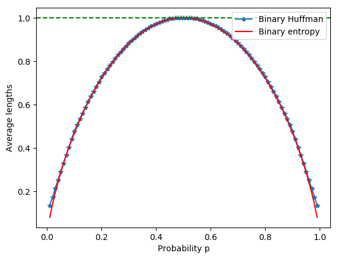

```
PyObject <matplotlib.legend.Legend object at 0x7fcca464d810>
```

```julia
plot(plist, avg_lengths, marker = "*", label = "Binary Huffman")
plot(plist, map(x->entropy([x,1-x]), plist), color = "r", label = "Binary entropy")  # binary entropy function
axhline(1, color = "g", linestyle = "--")
xlabel("Probability p")
ylabel("Average lengths")
legend(loc = "upper right", fancybox = "true")
```

Note that the average lengths are lower bounded by the binary entropy function.

#### (b) Find the average (over $p$) of the average length per symbol. Comment on how much a random Bernoulli source can be compressed on average.

The average length per symbol is

```julia
sum(avg_lengths)/length(avg_lengths)
```

```
0.7338590542828612
```

This value approximates the optimal compression ratio of the random Bernoulli source on average.

To be more precise, consider the random Bernoulli source $X|\{P=p\} \sim \textrm{Bern}(p)$ where $P\sim\textrm{Unif}[0,1]$. Then, given $P=p$, the optimal compression ratio of the source $X|\{P=p\}$ is $H(X|P=p)=H(p)$, and therefore on average the optimal compression ratio is $$H(X|P) = \int_0^1 H(X|P=p)dp = \int_0^1 H(p)dp = \frac{1}{2\ln(2)}.$$

```julia
1/2*log2(exp(1))
```

```
0.7213475204444817
```

You can check that our estimate is close to the true value.